# Sachs Protein Data

Valerie Monbet

7/10/2017

## Data

The [data](http://www.bnlearn.com/book-crc/code/sachs.data.txt.gz) consist in the simultaneous measurements of 11 phosphorylated proteins and phospholipids derived from thousands of individual primary immune system cells, subjected to both general and specific molecular interventions (Sachs et al., 2005).

Ref : Scutari, M., & Denis, J. B. (2014). Bayesian networks: with examples in R. CRC press.

```r
library(bnlearn)
```

```r
library(qgraph)

sachs <- read.table("sachs.data.txt", header = TRUE) # You have to download the data first
head(sachs)
```

```
##   praf  pmek  plcg  PIP2  PIP3 p44.42 pakts473 PKA   PKC  P38 pjnk
## 1 26.4 13.20  8.82 18.30 58.80   6.61     17.0 414 17.00 44.9 40.0
## 2 35.9 16.50 12.30 16.80  8.13  18.60     32.5 352  3.37 16.5 61.5
## 3 59.4 44.10 14.60 10.20 13.00  14.90     32.5 403 11.40 31.9 19.5
## 4 73.0 82.80 23.10 13.50  1.29   5.83     11.8 528 13.70 28.6 23.1
## 5 33.7 19.80  5.19  9.73 24.80  21.10     46.1 305  4.66 25.7 81.3
## 6 18.8  3.75 17.60 22.10 10.90  11.90     25.7 610 13.70 49.1 57.8
```

## First DAG

```r
dag.gs <- gs(sachs, test = "cor")
narcs(dag.gs)
```

```
## [1] 8
```

```r
directed.arcs(dag.gs)
```

```
##      from   to
## [1,] "P38"  "PKC"
## [2,] "pjnk" "PKC"
```

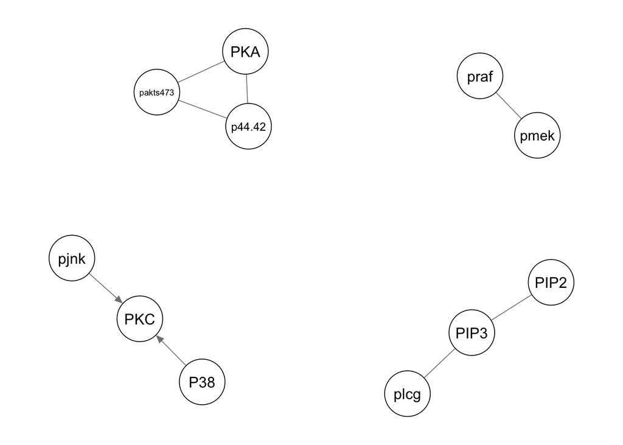

```r
qgraph(dag.gs)
```

This graph can be compared to the one of Sachs. Function model string allows to build a model string from a Bayesian network and vice versa.

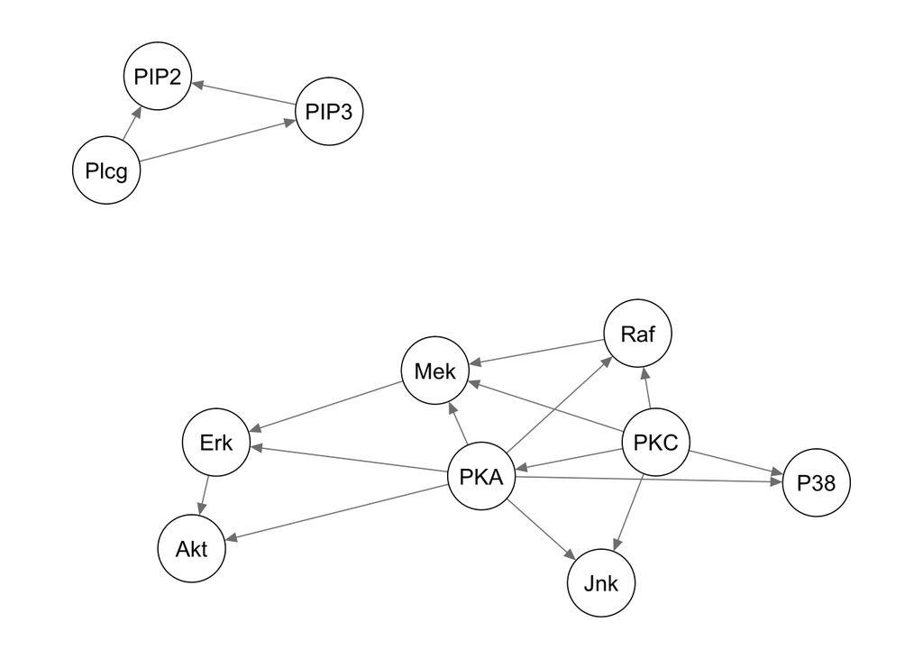

```r
sachs.modelstring <-
 paste("[PKC][PKA|PKC][Raf|PKC:PKA][Mek|PKC:PKA:Raf]",
 "[Erk|Mek:PKA][Akt|Erk:PKA][P38|PKC:PKA]",
 "[Jnk|PKC:PKA][Plcg][PIP3|Plcg][PIP2|Plcg:PIP3]",sep="")
dag.sachs <- model2network(sachs.modelstring)
qgraph(dag.sachs)
```

What are the differences between the two graphs?